# Supervised Learning - Foundations Project: ReCell

## Problem Statement

### Business Context

Buying and selling used phones and tablets used to be something that happened on a handful of online marketplace sites. But the used and refurbished device market has grown considerably over the past decade, and a new IDC (International Data Corporation) forecast predicts that the used phone market would be worth \$52.7bn by 2023 with a compound annual growth rate (CAGR) of 13.6% from 2018 to 2023. This growth can be attributed to an uptick in demand for used phones and tablets that offer considerable savings compared with new models.

Refurbished and used devices continue to provide cost-effective alternatives to both consumers and businesses that are looking to save money when purchasing one. There are plenty of other benefits associated with the used device market. Used and refurbished devices can be sold with warranties and can also be insured with proof of purchase. Third-party vendors/platforms, such as Verizon, Amazon, etc., provide attractive offers to customers for refurbished devices. Maximizing the longevity of devices through second-hand trade also reduces their environmental impact and helps in recycling and reducing waste. The impact of the COVID-19 outbreak may further boost this segment as consumers cut back on discretionary spending and buy phones and tablets only for immediate needs.

### Objective

The rising potential of this comparatively under-the-radar market fuels the need for an ML-based solution to develop a dynamic pricing strategy for used and refurbished devices. ReCell, a startup aiming to tap the potential in this market, has hired you as a data scientist. They want you to analyze the data provided and build a linear regression model to predict the price of a used phone/tablet and identify factors that significantly influence it.

### Data Description

The data contains the different attributes of used/refurbished phones and tablets. The data was collected in the year 2021. The detailed data dictionary is given below.

- brand_name: Name of manufacturing brand
- os: OS on which the device runs
- screen_size: Size of the screen in cm
- 4g: Whether 4G is available or not
- 5g: Whether 5G is available or not
- main_camera_mp: Resolution of the rear camera in megapixels
- selfie_camera_mp: Resolution of the front camera in megapixels
- int_memory: Amount of internal memory (ROM) in GB
- ram: Amount of RAM in GB
- battery: Energy capacity of the device battery in mAh
- weight: Weight of the device in grams
- release_year: Year when the device model was released
- days_used: Number of days the used/refurbished device has been used
- normalized_new_price: Normalized price of a new device of the same model in euros
- normalized_used_price: Normalized price of the used/refurbished device in euros

## Importing necessary libraries

```python
!pip install nb_black
```

```python
#libraries for panda and numpy for python
import pandas as pd
import numpy as np

#libraries for data visualization
import matplotlib.pyplot as plt
import warnings
import seaborn as sns
import pylab

# command to tell Python to display graphs
%matplotlib inline

# Library to help with statistical analysis
import scipy.stats as stats
import statsmodels.stats.api as sms
from statsmodels.compat import lzip

# load statmodels functions
from statsmodels.stats.outliers_influence import variance_inflation_factor
from statsmodels.tools.tools import add_constant

# command to load seaborn's default theme and color palette
sns.set()

# command to tell Python to ignore warnings
warnings.filterwarnings("ignore")

# to make the Python code more structured automatically (good coding practice)
%reload_ext nb_black

#Linear libraries hereafter :

# split the data into train and test
from sklearn.model_selection import train_test_split
from sklearn.model_selection import StratifiedKFold
from sklearn.preprocessing import MinMaxScaler
from sklearn.linear_model import LinearRegression

# To build linear regression_model
import statsmodels.api as sm

# to check model performance
from sklearn.metrics import mean_absolute_error, mean_squared_error, r2_score
```

## Loading the dataset

```python
# for mounting Google Drive to the notebook (to be used only if executing in Google Colab)
from google.colab import drive
drive.mount('/content/drive')

data = pd.read_csv('/content/drive/MyDrive/Colab Notebooks/Linear Regression/Project/used_device_data.csv')
```

## Data Overview

- Observations
- Sanity checks

The initial steps to get an overview of any dataset is to:

- observe the first and last few rows of the dataset, to check whether the dataset has been loaded properly or not
- validate information about the number of rows and columns in the dataset
- find out the data types of the columns to ensure that data is stored in the preferred format and the value of each property is as expected.
- check the statistical summary of the dataset to get an overview of the numerical columns of the data
- check if there are missing values in the dataset
- check the unique values of the dataset

### **Displaying the first and last few rows of the dataset**

```python
#observe the first few rows of the dataset

data.head()
```

|  | brand_name | os | screen_size | 4g | 5g | main_camera_mp | selfie_camera_mp | int_memory | ram | battery | weight | release_year | days_used | normalized_used_price | normalized_new_price |
| --- | --- | --- | --- | --- | --- | --- | --- | --- | --- | --- | --- | --- | --- | --- | --- |
| 0 | Honor | Android | 14.50 | yes | no | 13.0 | 5.0 | 64.0 | 3.0 | 3020.0 | 146.0 | 2020 | 127 | 4.307572 | 4.715100 |
| 1 | Honor | Android | 17.30 | yes | yes | 13.0 | 16.0 | 128.0 | 8.0 | 4300.0 | 213.0 | 2020 | 325 | 5.162097 | 5.519018 |
| 2 | Honor | Android | 16.69 | yes | yes | 13.0 | 8.0 | 128.0 | 8.0 | 4200.0 | 213.0 | 2020 | 162 | 5.111084 | 5.884631 |
| 3 | Honor | Android | 25.50 | yes | yes | 13.0 | 8.0 | 64.0 | 6.0 | 7250.0 | 480.0 | 2020 | 345 | 5.135387 | 5.630961 |
| 4 | Honor | Android | 15.32 | yes | no | 13.0 | 8.0 | 64.0 | 3.0 | 5000.0 | 185.0 | 2020 | 293 | 4.389995 | 4.947837 |

```python
#observe the last few rows of the dataset
data.tail()
```

|  | brand_name | os | screen_size | 4g | 5g | main_camera_mp | selfie_camera_mp | int_memory | ram | battery | weight | release_year | days_used | normalized_used_price | normalized_new_price |
| --- | --- | --- | --- | --- | --- | --- | --- | --- | --- | --- | --- | --- | --- | --- | --- |
| 3449 | Asus | Android | 15.34 | yes | no | NaN | 8.0 | 64.0 | 6.0 | 5000.0 | 190.0 | 2019 | 232 | 4.492337 | 6.483872 |
| 3450 | Asus | Android | 15.24 | yes | no | 13.0 | 8.0 | 128.0 | 8.0 | 4000.0 | 200.0 | 2018 | 541 | 5.037732 | 6.251538 |
| 3451 | Alcatel | Android | 15.80 | yes | no | 13.0 | 5.0 | 32.0 | 3.0 | 4000.0 | 165.0 | 2020 | 201 | 4.357350 | 4.528829 |
| 3452 | Alcatel | Android | 15.80 | yes | no | 13.0 | 5.0 | 32.0 | 2.0 | 4000.0 | 160.0 | 2020 | 149 | 4.349762 | 4.624188 |
| 3453 | Alcatel | Android | 12.83 | yes | no | 13.0 | 5.0 | 16.0 | 2.0 | 4000.0 | 168.0 | 2020 | 176 | 4.132122 | 4.279994 |

### **Get the info regarding the number of rows, column datatypes and other info**

```python
#get information about the number of rows and columns in the dataset

print('There is :',data.shape[0], 'rows and', data.shape[1], 'columns in the dataset')
```

```
There is : 3454 rows and 15 columns in the dataset
```

```python
#find out the data types of the columns to ensure that data is stored in the preferred format and the value of each property as expected.

data.info()
```

```
<class 'pandas.core.frame.DataFrame'>
RangeIndex: 3454 entries, 0 to 3453
Data columns (total 15 columns):
 #   Column                 Non-Null Count  Dtype
---  ------                 --------------  -----
 0   brand_name             3454 non-null   object
 1   os                     3454 non-null   object
 2   screen_size            3454 non-null   float64
 3   4g                     3454 non-null   object
 4   5g                     3454 non-null   object
 5   main_camera_mp         3275 non-null   float64
 6   selfie_camera_mp       3452 non-null   float64
 7   int_memory             3450 non-null   float64
 8   ram                    3450 non-null   float64
 9   battery                3448 non-null   float64
 10  weight                 3447 non-null   float64
 11  release_year           3454 non-null   int64
 12  days_used              3454 non-null   int64
 13  normalized_used_price  3454 non-null   float64
 14  normalized_new_price   3454 non-null   float64
dtypes: float64(9), int64(2), object(4)
memory usage: 404.9+ KB
```

```python
# Check to see if there are any missing data in each column, in descending order (i.e., from highest to lowest)
data.isnull().sum().sort_values(ascending=False)
```

```
main_camera_mp           179
weight                     7
battery                    6
int_memory                 4
ram                        4
selfie_camera_mp           2
brand_name                 0
os                         0
screen_size                0
4g                         0
5g                         0
release_year               0
days_used                  0
normalized_used_price      0
normalized_new_price       0
dtype: int64
```

```python
# checking for unique values of each column
data.nunique()
```

```
brand_name                 34
os                          4
screen_size               142
4g                          2
5g                          2
main_camera_mp             41
selfie_camera_mp           37
int_memory                 15
ram                        12
battery                   324
weight                    555
release_year                8
days_used                 924
normalized_used_price    3094
normalized_new_price     2988
dtype: int64
```

```python
# check value counts for "brand_name" column
data["brand_name"].value_counts()
```

```
Others        502
Samsung       341
Huawei        251
LG            201
Lenovo        171
ZTE           140
Xiaomi        132
Oppo          129
Asus          122
Alcatel       121
Micromax      117
Vivo          117
Honor         116
HTC           110
Nokia         106
Motorola      106
Sony           86
Meizu          62
Gionee         56
Acer           51
XOLO           49
Panasonic      47
Realme         41
Apple          39
Lava           36
Celkon         33
Spice          30
Karbonn        29
Coolpad        22
BlackBerry     22
Microsoft      22
OnePlus        22
Google         15
Infinix        10
Name: brand_name, dtype: int64
```

```python
# check value counts for "OS" column
data["os"].value_counts()
```

```
Android    3214
Others      137
Windows      67
iOS          36
Name: os, dtype: int64
```

```python
# check value counts for "4G" column
data["4g"].value_counts()
```

```
yes    2335
no     1119
Name: 4g, dtype: int64
```

```python
# check value counts for "5G" column
data["5g"].value_counts()
```

```
no     3302
yes     152
Name: 5g, dtype: int64
```

*Observation :*

1. There are 3454 rows and 15 columns in the dataset
2. There are some missing values in some of the columns. Main_camera_mp has the highest messing value of 179 records. We will need to analyze further and fix all te missing vaues
3. There are 11 numeric (float and int type) and 4 string (object type) columns in the dataset
4. brand_name, os, 4g and 5g are categorical while all others are numerical data types
5. The target (dependent) variable normalized_used_price, and independent variable normalized_new_price are of float type. The “target variable” is the variable whose values are to be modeled and predicted by other variables
6. Tehre are 34 unique phone brandnames marketed by ReCell. We may need to drop this column due to its large category after one-hot encode to avoid dummy variable trap
7. There are 4 unique types of OS only with most popular OS being Android ~ Approx 93% of ReCell market (3214 phones)
8. Only 68% of which are 4G phones (2335 phones) make up ReCell's market while only 4% (3454-3302 = 152 phones) have 5G

### **Analyze info regarding the missing values**

*Analyzing missing values for Main_Caamera_mp column*

```python
# Create a data frame for main camera mega pixels missing values

missing_main_mp = data[data["main_camera_mp"].isnull()]
missing_main_mp.head(10)
```

|  | brand_name | os | screen_size | 4g | 5g | main_camera_mp | selfie_camera_mp | int_memory | ram | battery | weight | release_year | days_used | normalized_used_price | normalized_new_price |
| --- | --- | --- | --- | --- | --- | --- | --- | --- | --- | --- | --- | --- | --- | --- | --- |
| 59 | Infinix | Android | 17.32 | yes | no | NaN | 8.0 | 32.0 | 2.0 | 6000.0 | 209.0 | 2020 | 245 | 4.282068 | 4.597642 |
| 60 | Infinix | Android | 15.39 | yes | no | NaN | 8.0 | 64.0 | 4.0 | 5000.0 | 185.0 | 2020 | 173 | 4.363608 | 4.711780 |
| 61 | Infinix | Android | 15.39 | yes | no | NaN | 8.0 | 32.0 | 2.0 | 5000.0 | 185.0 | 2020 | 256 | 4.181439 | 4.505460 |
| 62 | Infinix | Android | 15.39 | yes | no | NaN | 16.0 | 32.0 | 3.0 | 4000.0 | 178.0 | 2019 | 316 | 4.555244 | 4.602166 |
| 63 | Infinix | Android | 15.29 | yes | no | NaN | 16.0 | 32.0 | 2.0 | 4000.0 | 165.0 | 2019 | 468 | 4.416670 | 4.871297 |
| 64 | Lava | Android | 14.50 | yes | no | NaN | 5.0 | 32.0 | 2.0 | 3200.0 | 150.0 | 2020 | 356 | 3.989910 | 4.381026 |
| 97 | Meizu | Android | 15.39 | yes | yes | NaN | 20.0 | 128.0 | 8.0 | 4500.0 | 199.0 | 2020 | 186 | 5.167867 | 6.272028 |
| 98 | Meizu | Android | 15.37 | yes | no | NaN | 16.0 | 128.0 | 6.0 | 4500.0 | 183.0 | 2019 | 449 | 4.665512 | 5.526329 |
| 99 | Meizu | Android | 15.37 | yes | no | NaN | 8.0 | 32.0 | 2.0 | 4000.0 | 184.0 | 2019 | 190 | 4.290185 | 5.195177 |
| 100 | Meizu | Android | 15.29 | yes | no | NaN | 20.0 | 128.0 | 6.0 | 3600.0 | 166.0 | 2019 | 459 | 4.721085 | 5.830679 |

```python
missing_main_mp["brand_name"].value_counts()
```

```
Realme        36
Xiaomi        23
Oppo          20
Motorola      18
OnePlus       17
Meizu         15
Vivo          14
Infinix       10
Sony           7
ZTE            4
Asus           4
BlackBerry     4
Coolpad        3
Lava           2
Panasonic      2
Name: brand_name, dtype: int64
```

```python
missing_main_mp["os"].value_counts()
```

```
Android    179
Name: os, dtype: int64
```

*Analyzing missing values for phone weight column*

```python
# Creating a data frame for weight missing values

missing_weight = data[data["weight"].isnull()]
missing_weight.head(10)
```

|  | brand_name | os | screen_size | 4g | 5g | main_camera_mp | selfie_camera_mp | int_memory | ram | battery | weight | release_year | days_used | normalized_used_price | normalized_new_price |
| --- | --- | --- | --- | --- | --- | --- | --- | --- | --- | --- | --- | --- | --- | --- | --- |
| 3002 | XOLO | Android | 12.70 | yes | no | 13.0 | 5.0 | 32.0 | 4.0 | 2400.0 | NaN | 2015 | 576 | 4.165890 | 4.930437 |
| 3003 | XOLO | Android | 12.83 | yes | no | 8.0 | 5.0 | 16.0 | 4.0 | 3200.0 | NaN | 2015 | 800 | 4.282068 | 5.189228 |
| 3004 | XOLO | Android | 12.70 | no | no | 8.0 | 2.0 | 32.0 | 4.0 | 2100.0 | NaN | 2015 | 878 | 3.879706 | 4.081090 |
| 3005 | XOLO | Android | 10.29 | no | no | 5.0 | 0.3 | 32.0 | 4.0 | 1800.0 | NaN | 2015 | 1036 | 3.823847 | 4.396053 |
| 3006 | XOLO | Android | 12.70 | no | no | 5.0 | 0.3 | 16.0 | 4.0 | 2500.0 | NaN | 2015 | 679 | 3.837084 | 4.347176 |
| 3007 | XOLO | Windows | 12.70 | no | no | 8.0 | 2.0 | 32.0 | 4.0 | 2200.0 | NaN | 2015 | 838 | 3.707210 | 4.791733 |
| 3008 | XOLO | Android | 12.70 | no | no | 8.0 | 5.0 | 32.0 | 4.0 | 2500.0 | NaN | 2015 | 1045 | 4.184642 | 4.785406 |

*Analyzing missing values for battery column*

```python
# Creating a data frame for battery column missing values

missing_battery = data[data["battery"].isnull()]
missing_battery.head(10)
```

|  | brand_name | os | screen_size | 4g | 5g | main_camera_mp | selfie_camera_mp | int_memory | ram | battery | weight | release_year | days_used | normalized_used_price | normalized_new_price |
| --- | --- | --- | --- | --- | --- | --- | --- | --- | --- | --- | --- | --- | --- | --- | --- |
| 1829 | Meizu | Android | 12.83 | yes | no | 13.0 | 5.0 | 16.00 | 4.00 | NaN | 145.0 | 2014 | 986 | 4.177919 | 4.863604 |
| 1831 | Meizu | Android | 12.83 | yes | no | 20.7 | 5.0 | 16.00 | 4.00 | NaN | 158.0 | 2014 | 1043 | 4.878855 | 5.990639 |
| 1832 | Meizu | Android | 13.61 | yes | no | 20.7 | 2.0 | 16.00 | 4.00 | NaN | 147.0 | 2014 | 1007 | 4.742320 | 5.826118 |
| 1962 | Microsoft | Windows | 25.55 | no | no | 5.0 | 3.5 | 32.00 | 4.00 | NaN | 675.9 | 2013 | 931 | 5.230574 | 5.802753 |
| 2058 | Nokia | Others | 5.18 | no | no | 0.3 | 0.0 | 0.06 | 0.02 | NaN | 81.0 | 2016 | 815 | 2.718660 | 3.374511 |
| 2059 | Nokia | Others | 5.18 | no | no | 0.3 | 0.0 | 0.06 | NaN | NaN | 82.6 | 2016 | 1023 | 2.765060 | 3.657905 |

*Analyzing missing values for intenal memory column*

```python
# Creating a data frame for internal memory column missing values

missing_int_memory = data[data["int_memory"].isnull()]
missing_int_memory.head(10)
```

|  | brand_name | os | screen_size | 4g | 5g | main_camera_mp | selfie_camera_mp | int_memory | ram | battery | weight | release_year | days_used | normalized_used_price | normalized_new_price |
| --- | --- | --- | --- | --- | --- | --- | --- | --- | --- | --- | --- | --- | --- | --- | --- |
| 117 | Nokia | Others | 5.18 | yes | no | 0.3 | 0.0 | NaN | 0.02 | 1200.0 | 86.5 | 2019 | 234 | 2.721295 | 3.688379 |
| 2035 | Nokia | Others | 5.18 | no | no | 5.0 | 0.0 | NaN | 0.03 | 1020.0 | 157.0 | 2019 | 501 | 2.343727 | 3.420346 |
| 2064 | Nokia | Others | 5.18 | no | no | 0.3 | 0.0 | NaN | 0.02 | 1100.0 | 78.4 | 2015 | 559 | 2.587012 | 3.378611 |
| 2092 | Nokia | Others | 7.62 | no | no | 5.0 | 0.0 | NaN | 0.02 | 1010.0 | 100.0 | 2013 | 1043 | 3.535728 | 4.370586 |

*Analyzing missing values for RAM column*

```python
# Creating a data frame for RAM column missing values

missing_RAM = data[data["ram"].isnull()]
missing_RAM.head(10)
```

|  | brand_name | os | screen_size | 4g | 5g | main_camera_mp | selfie_camera_mp | int_memory | ram | battery | weight | release_year | days_used | normalized_used_price | normalized_new_price |
| --- | --- | --- | --- | --- | --- | --- | --- | --- | --- | --- | --- | --- | --- | --- | --- |
| 114 | Nokia | Others | 5.18 | no | no | 0.3 | 0.0 | 0.06 | NaN | 1020.0 | 91.3 | 2020 | 288 | 2.729159 | 2.911263 |
| 335 | Nokia | Others | 5.18 | no | no | 0.3 | 0.0 | 0.10 | NaN | 1200.0 | 88.2 | 2020 | 327 | 3.062924 | 3.689129 |
| 2059 | Nokia | Others | 5.18 | no | no | 0.3 | 0.0 | 0.06 | NaN | NaN | 82.6 | 2016 | 1023 | 2.765060 | 3.657905 |
| 2090 | Nokia | Others | 7.62 | no | no | 5.0 | 0.0 | 0.06 | NaN | 1200.0 | 111.4 | 2013 | 1001 | 3.827771 | 4.605770 |

*Analyzing missing values for Selfie Camera MP column*

```python
# Creating a data frame for slefie camera MP column missing values

missing_selfie_MP = data[data["selfie_camera_mp"].isnull()]
missing_selfie_MP.head(10)
```

|  | brand_name | os | screen_size | 4g | 5g | main_camera_mp | selfie_camera_mp | int_memory | ram | battery | weight | release_year | days_used | normalized_used_price | normalized_new_price |
| --- | --- | --- | --- | --- | --- | --- | --- | --- | --- | --- | --- | --- | --- | --- | --- |
| 1080 | Google | Android | 15.32 | yes | no | 12.2 | NaN | 64.0 | 4.0 | 3430.0 | 184.0 | 2018 | 475 | 5.573826 | 6.865974 |
| 1081 | Google | Android | 12.83 | yes | no | 12.2 | NaN | 64.0 | 4.0 | 2915.0 | 148.0 | 2018 | 424 | 4.464988 | 6.745083 |

*Summary and Conclusion of Missing Values*

- The missing values for Main Camera MP were found mostly for Android phones of various brands
- The missing values for phone weights were found for Android phones and one Windows phone for XOLO brands only
- The missing values for phone batteries were found for few Android phones, one Windows phone and 2 other unmentioned OS for 3 other different brand names of phone
- There are four missing values of phone RAM all belonging to Nokia brand
- There are four missing values of phone Internal Memory belonging to Nokia brand as well in different rows
- All 8 rows of data for Nokia brand OS belongs to Others
- From my perspective on the missng values, it would be better to impute the missing values with the median of the columns during data preprocessing. We would select the device brand-name and since we have time-series data (release year), we might want to group by date or time as well.

### **Get summary statistics for the numerical columns**

```python
data.describe().T
```

|  | count | mean | std | min | 25% | 50% | 75% | max |
| --- | --- | --- | --- | --- | --- | --- | --- | --- |
| screen_size | 3454.0 | 13.713115 | 3.805280 | 5.080000 | 12.700000 | 12.830000 | 15.340000 | 30.710000 |
| main_camera_mp | 3275.0 | 9.460208 | 4.815461 | 0.080000 | 5.000000 | 8.000000 | 13.000000 | 48.000000 |
| selfie_camera_mp | 3452.0 | 6.554229 | 6.970372 | 0.000000 | 2.000000 | 5.000000 | 8.000000 | 32.000000 |
| int_memory | 3450.0 | 54.573099 | 84.972371 | 0.010000 | 16.000000 | 32.000000 | 64.000000 | 1024.000000 |
| ram | 3450.0 | 4.036122 | 1.365105 | 0.020000 | 4.000000 | 4.000000 | 4.000000 | 12.000000 |
| battery | 3448.0 | 3133.402697 | 1299.682844 | 500.000000 | 2100.000000 | 3000.000000 | 4000.000000 | 9720.000000 |
| weight | 3447.0 | 182.751871 | 88.413228 | 69.000000 | 142.000000 | 160.000000 | 185.000000 | 855.000000 |
| release_year | 3454.0 | 2015.965258 | 2.298455 | 2013.000000 | 2014.000000 | 2015.500000 | 2018.000000 | 2020.000000 |
| days_used | 3454.0 | 674.869716 | 248.580166 | 91.000000 | 533.500000 | 690.500000 | 868.750000 | 1094.000000 |
| normalized_used_price | 3454.0 | 4.364712 | 0.588914 | 1.536867 | 4.033931 | 4.405133 | 4.755700 | 6.619433 |
| normalized_new_price | 3454.0 | 5.233107 | 0.683637 | 2.901422 | 4.790342 | 5.245892 | 5.673718 | 7.847841 |

## Exploratory Data Analysis (EDA)

- EDA is an important part of any project involving data.
- It is important to investigate and understand the data better before building a model with it.
- A few questions have been mentioned below which will help you approach the analysis in the right manner and generate insights from the data.
- A thorough analysis of the data, in addition to the questions mentioned below, should be done.

**Questions**:

1. What does the distribution of normalized used device prices look like?
2. What percentage of the used device market is dominated by Android devices?
3. The amount of RAM is important for the smooth functioning of a device. How does the amount of RAM vary with the brand?
4. A large battery often increases a device's weight, making it feel uncomfortable in the hands. How does the weight vary for phones and tablets offering large batteries (more than 4500 mAh)?
5. Bigger screens are desirable for entertainment purposes as they offer a better viewing experience. How many phones and tablets are available across different brands with a screen size larger than 6 inches?
6. A lot of devices nowadays offer great selfie cameras, allowing us to capture our favorite moments with loved ones. What is the distribution of devices offering greater than 8MP selfie cameras across brands?
7. Which attributes are highly correlated with the normalized price of a used device?

### *Univariate Analysis*

```python
# function to plot a boxplot and a histogram along the same scale.


def histogram_boxplot(data, feature, figsize=(15, 10), kde=True, bins=None):
    """
    Boxplot and histogram combined

    data: dataframe
    feature: dataframe column
    figsize: size of figure (default (15,10))
    kde: whether to show the density curve (default False)
    bins: number of bins for histogram (default None)
    """
    f2, (ax_box2, ax_hist2) = plt.subplots(
        nrows=2,  # Number of rows of the subplot grid= 2
        sharex=True,  # x-axis will be shared among all subplots
        gridspec_kw={"height_ratios": (0.25, 0.75)},
        figsize=figsize,
    )  # creating the 2 subplots
    sns.boxplot(
        data=data, x=feature, ax=ax_box2, showmeans=True, color="violet"
    )  # boxplot will be created and a triangle will indicate the mean value of the column
    sns.histplot(
        data=data, x=feature, kde=kde, ax=ax_hist2, bins=bins
    ) if bins else sns.histplot(
        data=data, x=feature, kde=kde, ax=ax_hist2
    )  # For histogram
    ax_hist2.axvline(
        data[feature].mean(), color="green", linestyle="--"
    )  # Add mean to the histogram
    ax_hist2.axvline(
        data[feature].median(), color="black", linestyle="-"
    )  # Add median to the histogram
```

```python
# function to create labeled barplots

def labeled_barplot(data, feature, perc=False, n=None):
    """
    Barplot with percentage at the top

    data: dataframe
    feature: dataframe column
    perc: whether to display percentages instead of count (default is False)
    n: displays the top n category levels (default is None, i.e., display all levels)
    """

    total = len(data[feature])  # length of the column
    count = data[feature].nunique()
    if n is None:
        plt.figure(figsize=(count + 2, 6))
    else:
        plt.figure(figsize=(n + 2, 6))

    plt.xticks(rotation=90, fontsize=15)
    ax = sns.countplot(
        data=data,
        x=feature,
        palette="Paired",
        order=data[feature].value_counts().index[:n],
    )

    for p in ax.patches:
        if perc == True:
            label = "{:.1f}%".format(
                100 * p.get_height() / total
            )  # percentage of each class of the category
        else:
            label = p.get_height()  # count of each level of the category

        x = p.get_x() + p.get_width() / 2  # width of the plot
        y = p.get_height()  # height of the plot

        ax.annotate(
            label,
            (x, y),
            ha="center",
            va="center",
            size=12,
            xytext=(0, 5),
            textcoords="offset points",
        )  # annotate the percentage

    plt.show()  # show the plot
```

**1. Distribution of normalized used device prices*

```python
data["normalized_used_price"].describe()
```

```
count    3454.000000
mean        4.364712
std         0.588914
min         1.536867
25%         4.033931
50%         4.405133
75%         4.755700
max         6.619433
Name: normalized_used_price, dtype: float64
```

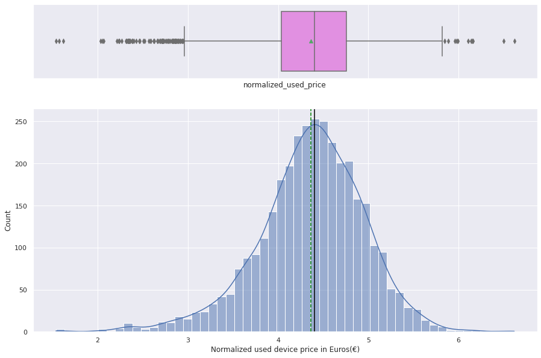

```python
histogram_boxplot(data,"normalized_used_price")
plt.xlabel("Normalized used device price in Euros(€)");
```

*Observation*

- The mean value of the normalized used price is 4.364712, which indicates that the average used price of the product is around 4 times the original price.
- The std dev of the data is 0.589, which is low, indicating that the data is tightly clustered around the mean.
- The standard deviation of 0.588914 also indicates that there is relatively low variability in the used price of the product. Tht suggests that the used price of the product is relatively consistent or has low variability around the mean value of 4.364712.
- The 25th percentile value of 4.033931 and 75th percentile value of 4.755700 suggest that most of the used products fall within this price range.

* *2.Distribution of normalized new device prices*

```python
data["normalized_new_price"].describe()
```

```
count    3454.000000
mean        5.233107
std         0.683637
min         2.901422
25%         4.790342
50%         5.245892
75%         5.673718
max         7.847841
Name: normalized_new_price, dtype: float64
```

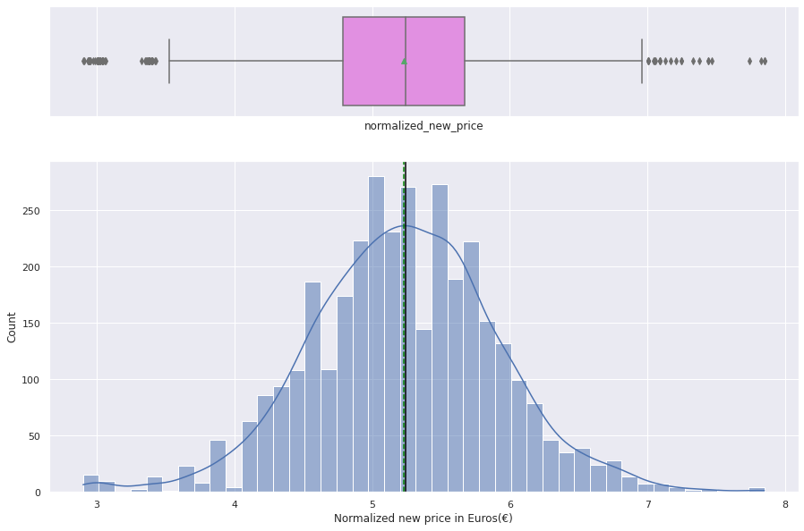

```python
histogram_boxplot(data,"normalized_new_price")
plt.xlabel("Normalized new price in Euros(€)");
```

*Observation*

- The mean value of the normalized new price is 5.233107, which indicates that the average new price of the product is around 5 times the original price.
- The std dev of the data is 0.683, which indicates that the values in the dataset are relatively spread out from the mean.
- The standard deviation of 0.683637 also indicates that there is moderate variability in the new price of the product.
- The minimum value approximately 2.90, while the maximum value is approximately 7.85 suggesting that there may be some outliers and also indicates that there is a wide range in the new price of the product.
- The 25th percentile value of 4.790342 and 75th percentile value of 5.673718 suggest that most of the new products fall within this price range.
- The median value (50th percentile) of the data is approximately 5.25, which is close to the mean value, indicating that the data is likely roughly symmetric.

**3. Number of days the used/refurbished device has been used*

```python
data["days_used"].describe()
```

```
count    3454.000000
mean      674.869716
std       248.580166
min        91.000000
25%       533.500000
50%       690.500000
75%       868.750000
max      1094.000000
Name: days_used, dtype: float64
```

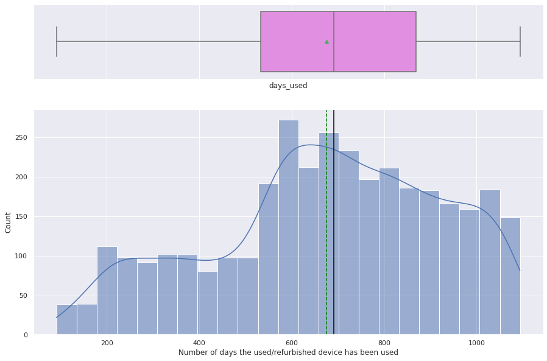

```python
histogram_boxplot(data,"days_used")
plt.xlabel("Number of days the used/refurbished device has been used");
```

*Observation*

- The mean value of the data is approximately 674.87. This means on average, the products have been used for around 2 years before being resold.
- The standard deviation of the data is approximately 248.58, indicating that the values in the dataset are relatively spread out from the mean.
- The standard deviation also indicates that there is a significant amount of variability in the number of days the product has been used. This suggests that some products may be in better condition than others, and that the resale value of each product may vary based on its condition.

**4. Year when device was released*

```python
data["release_year"].describe()
```

```
count    3454.000000
mean     2015.965258
std         2.298455
min      2013.000000
25%      2014.000000
50%      2015.500000
75%      2018.000000
max      2020.000000
Name: release_year, dtype: float64
```

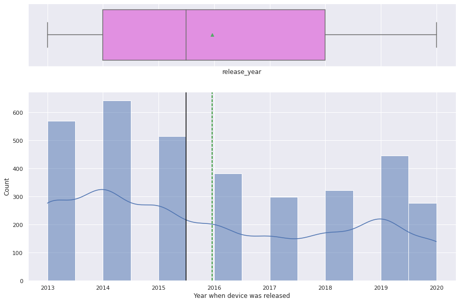

```python
histogram_boxplot(data,"release_year")
plt.xlabel("Year when device was released");
```

*Observation*

- The mean release year is 2015.97, indicating that the majority of phones in the dataset were likely released around this time.
- The interquartile range (IQR) for the release year is also relatively small (4 years), indicating that the majority of the devices in the dataset were released within a narrow time frame.
- The standard deviation of the release year variable is relatively small (2.298455), indicating that the release year values are not very spread out around the mean value. This further supports the idea that the distribution may be relatively narrow.
- The minimum value of the release year is 2013, and the maximum value is 2020. This suggests that the dataset includes devices that were released over a period of 8 years.
- The median release year (50th percentile) is approximately 2015.5, which is close to the mean. This suggests that the distribution of release years may be relatively symmetrical and approximately normal.

**5. Weight of ReCell devices in grams*

```python
data["weight"].describe()
```

```
count    3447.000000
mean      182.751871
std        88.413228
min        69.000000
25%       142.000000
50%       160.000000
75%       185.000000
max       855.000000
Name: weight, dtype: float64
```

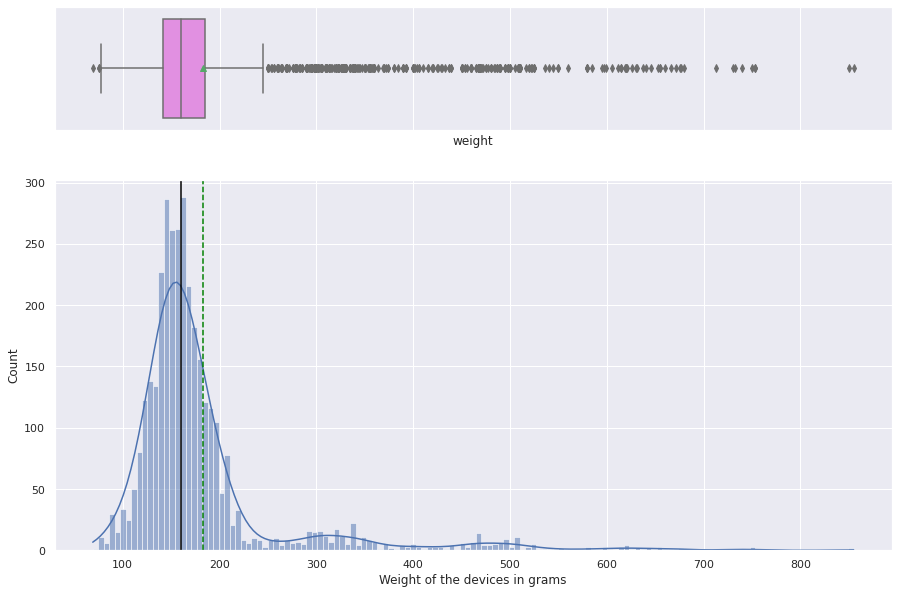

```python
histogram_boxplot(data,"weight")
plt.xlabel("Weight of the devices in grams");
```

*Observation*

**6. Energy capacity of devices in mAh*

```python
data["battery"].describe()
```

```
count    3448.000000
mean     3133.402697
std      1299.682844
min       500.000000
25%      2100.000000
50%      3000.000000
75%      4000.000000
max      9720.000000
Name: battery, dtype: float64
```

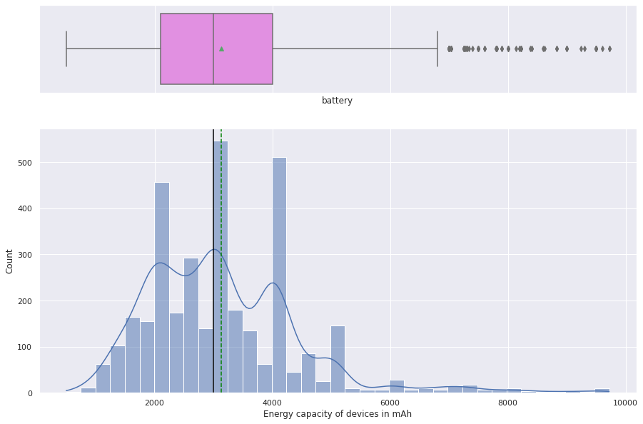

```python
histogram_boxplot(data,"battery")
plt.xlabel("Energy capacity of devices in mAh");
```

*Observation*

**7. Amount of RAM in GB*

```python
data["ram"].describe()
```

```
count    3450.000000
mean        4.036122
std         1.365105
min         0.020000
25%         4.000000
50%         4.000000
75%         4.000000
max        12.000000
Name: ram, dtype: float64
```

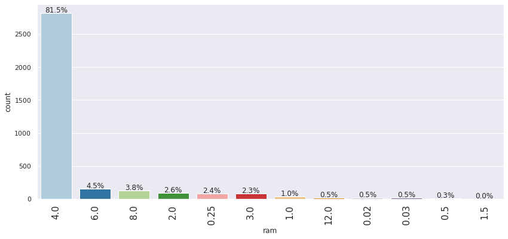

```python
labeled_barplot(data, "ram", perc=True)
```

*Observation*

- The mean amount of RAM for the devices at ReCell is 4.03GB, indicating that this is a common amount of RAM among the devices in the dataset.
- The 25th, 50th, and 75th percentiles are all 4.000000, which indicates that the data is heavily concentrated around this value.
- Overall, the data suggests that the majority of devices in the dataset have 4GB of RAM, with some variability around this value.

**8. Amount of Internal Memory (ROM) in GB*

```python
data["int_memory"].describe()
```

```
count    3450.000000
mean       54.573099
std        84.972371
min         0.010000
25%        16.000000
50%        32.000000
75%        64.000000
max      1024.000000
Name: int_memory, dtype: float64
```

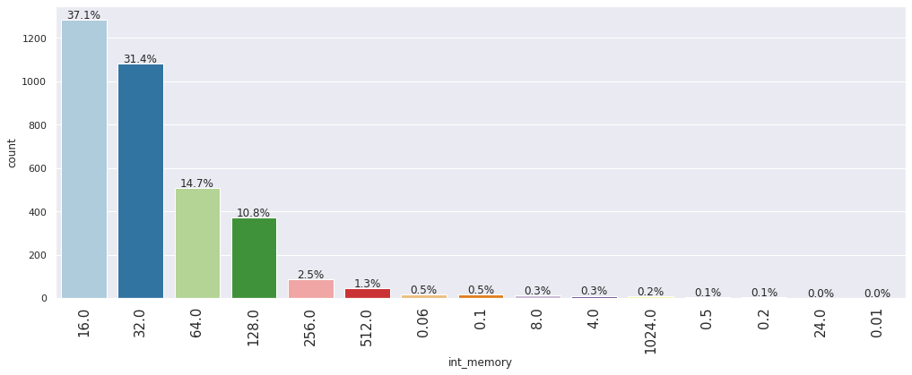

```python
labeled_barplot(data, "int_memory", perc=True)
```

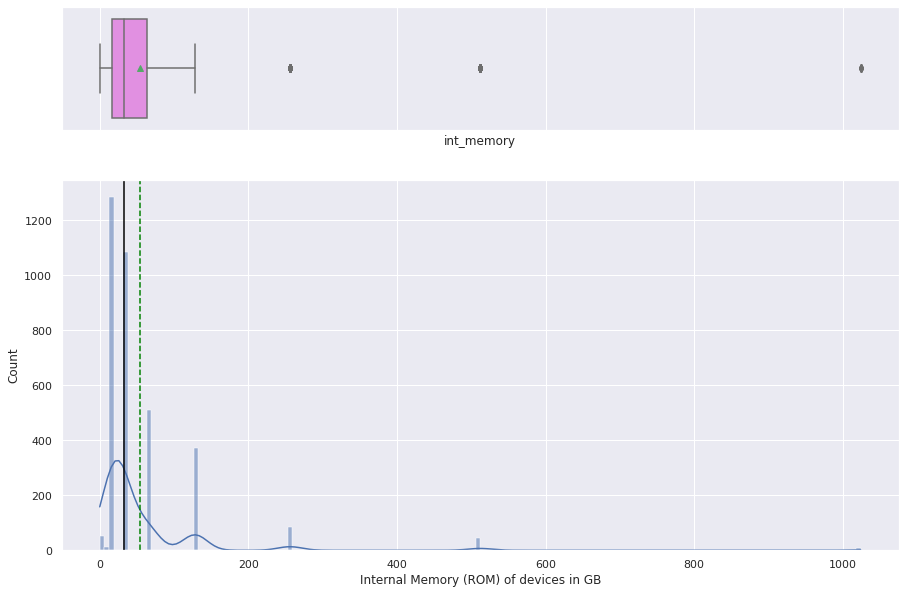

```python
histogram_boxplot(data,"int_memory")
plt.xlabel("Internal Memory (ROM) of devices in GB");
```

*Observation*

- The average internal memory size in the sample population is 54.55GB.
- The standard deviation of internal memory size indicates that the values in the dataset is largely spread out from the mean.
- The smallest device internal memory is 0.01GB (10MB) and the largest is 1024GB (1TB).
- The majority of the device internal memory size (50%) falls between 16 GB and 64 GB.
- There is a wide spread of internal memory sizes, as evidenced by the large difference between the minimum and maximum values, as well as the spread of values between the 25th and 75th percentiles.
- There may be some outliers in the data, as the maximum value is much larger than the values at the 75th percentile.

**9. Brand Name*

```python
data["brand_name"].describe()
```

```
count       3454
unique        34
top       Others
freq         502
Name: brand_name, dtype: object
```

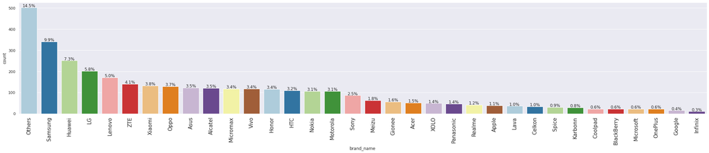

```python
labeled_barplot(data, "brand_name", perc=True)
```

*Observation*

- The highest value of brandname is not given, falling under the category of others.
- After Others, Samsung brand have a higher percentage indicating that customers tend to buy refurbished Samsug phones.

**10. OS : Analysis on Device OS*

```python
data["os"].describe()
```

```
count        3454
unique          4
top       Android
freq         3214
Name: os, dtype: object
```

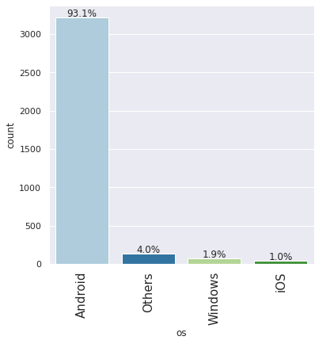

```python
labeled_barplot(data, "os", perc=True)
```

*Observation*

- There are 4 unique types of OS only with most popular refurbished OS being Android ~ Approx 93% of ReCell market
- iOS devices are the least refurbished with a percentage of 1.0% in the refurbished market

**11. Screen Size : Device Screen Size in cm*

```python
data["screen_size"].describe()
```

```
count    3454.000000
mean       13.713115
std         3.805280
min         5.080000
25%        12.700000
50%        12.830000
75%        15.340000
max        30.710000
Name: screen_size, dtype: float64
```

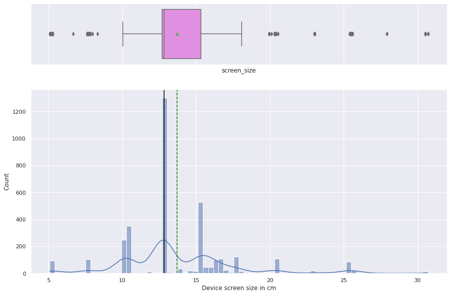

```python
histogram_boxplot(data,"screen_size")
plt.xlabel("Device screen size in cm");
```

*Observation*

- The average phone screen size in the sample population is 13.71 cm.
- The standard deviation of phone screen sizes is 3.81, indicating that there is some variability in the data.
- The smallest phone screen size in the sample or population is 5.08cm and the largest is 30.71cm.
- The majority of phone screen sizes (50%) fall between 12.70 and 15.34 cm.
- There is a relatively wide range of phone screen sizes, as evidenced by the large difference between the minimum and maximum values, as well as the spread of values between the 25th and 75th percentiles.
- The boxplot shows outliers present forthe dataset

**12. 4G and 5G Devices*

```
yes    2335
no     1119
Name: 4g, dtype: int64
```

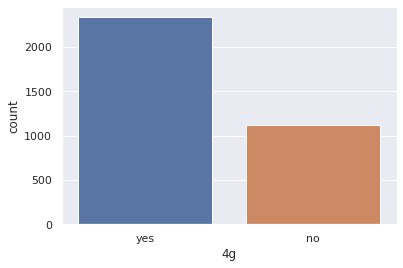

```python
print(data['4g'].value_counts())

sns.countplot(data=data, x="4g");
```

```python
data["4g"].describe()
```

```
count     3454
unique       2
top        yes
freq      2335
Name: 4g, dtype: object
```

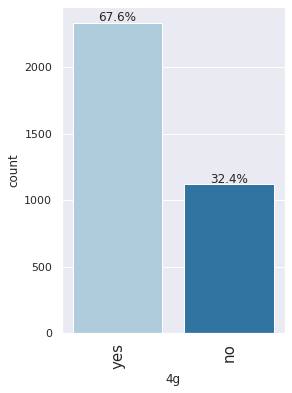

```python
labeled_barplot(data, "4g", perc=True)
```

```
no     3302
yes     152
Name: 5g, dtype: int64
```

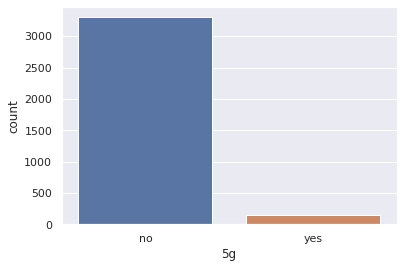

```python
print(data['5g'].value_counts())

sns.countplot(data=data, x="5g");
```

```python
data["5g"].describe()
```

```
count     3454
unique       2
top         no
freq      3302
Name: 5g, dtype: object
```

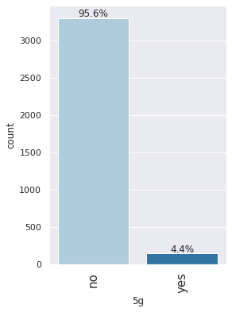

```python
labeled_barplot(data, "5g", perc=True)
```

*Observation*

- 68% of ReCell's devices carried has 4G capability as compared to 5G having only 4%

**13. Devices with Rear Camera Megapixels*

```python
data["main_camera_mp"].describe()
```

```
count    3275.000000
mean        9.460208
std         4.815461
min         0.080000
25%         5.000000
50%         8.000000
75%        13.000000
max        48.000000
Name: main_camera_mp, dtype: float64
```

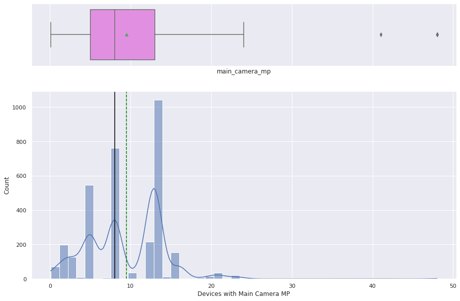

```python
histogram_boxplot(data,"main_camera_mp")
plt.xlabel("Devices with Main Camera MP");
```

*Observation*

**14. Devices of Selfie Camera Megapixels*

```python
data["selfie_camera_mp"].describe()
```

```
count    3452.000000
mean        6.554229
std         6.970372
min         0.000000
25%         2.000000
50%         5.000000
75%         8.000000
max        32.000000
Name: selfie_camera_mp, dtype: float64
```

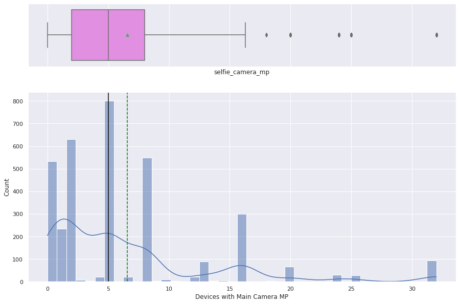

```python
histogram_boxplot(data,"selfie_camera_mp")
plt.xlabel("Devices with Main Camera MP");
```

Observation

- Selfie camera megapixels distribution appears to be right-skewed as well
- The standard deviation (std) of 6.97 indicates that the values in the dataset are somewhat spread out from the mean of 6.55.
- The average camera megapixel for the phone datasets is 6.55MP
- The smallest main camera megapixel is 0MP, and the largest is 32MP.
- The majority of the selfie camera megapixel (50%) fall between 2MP and 8MP.

### *Bivariate Analysis*

*Correlation heatmap*

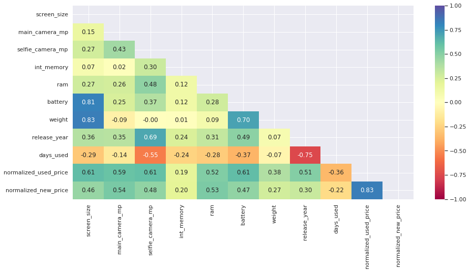

```python
# Create a mask with lower triangle
corr = data.corr()
mask = np.triu(np.ones_like(corr, dtype=bool))

# correlation heatmap
plt.figure(figsize=(15, 7))
sns.heatmap(
    data.corr(), annot=True, vmin=-1, vmax=1, fmt=".2f", cmap="Spectral", mask=mask,
)
plt.show()
```

**Correlated Attributes Observation:**

- Strong Positive Correlation :
  - Normalized price of a used device is highly correlated with Normalized new_price which means that the higher the new price, the higher the used price
  - A correlation coeeficient of 0.83 between device screen size and weight suggests a strong positive correlation which could imply that as the screen size of a device increases, the weight of the device tends to increase as well.
- Moderate Positive Correlation :
  - Used price is also moderately correlated to the device choice of selfie_camera_mp, screen size and battery meaning the higher the selection for selfie-mp or screen size, the higher the used phone price can be as well.
- Strong Negative Correlation :
  - A correlation coefficient of -0.75 between device days used and release year suggests a strong negative linear relationship between the two variables. This could means that as the phone release year increases, the number of days the phone is used decreases. It also could mean that newer phones tend to be used for a shorter amount of time compared to older phones.

**Normalized Used Price vs Normalized New Price**

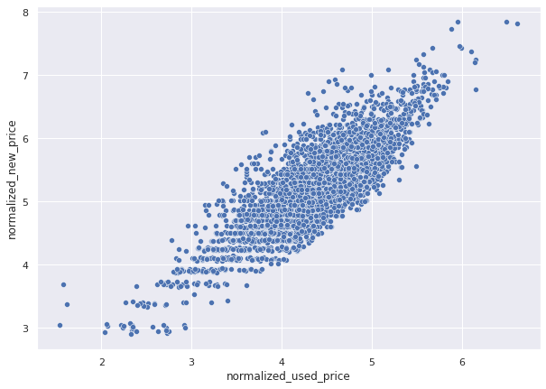

```python
plt.figure(figsize=(10, 7))
sns.scatterplot(data=data, x="normalized_used_price", y="normalized_new_price");

plt.show()
```

**Observations**

- A positive trend is noticed in this scatterplot as confirmed by the correlation heatmap.
- The higher the used price, new price increases as well. A strong positive linear relationship is apparent.

**Normalized Used Price vs Days Used**

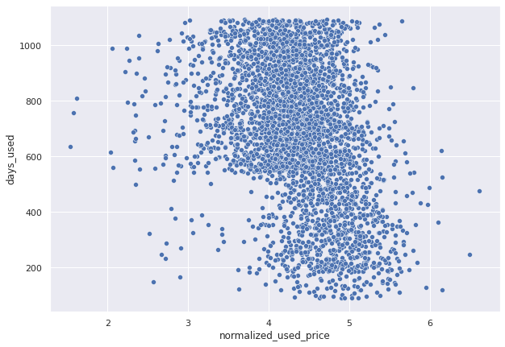

```python
plt.figure(figsize=(10, 7))
sns.scatterplot(data=data, x="normalized_used_price", y="days_used");

plt.show()
```

**Observations**

- A weak negative trend is noticed in this scatterplot as confirmed by the correlation heatmap
- This means that as the number of days a used/refurbished phone has been used increases, the normalized price of the phone tends to decrease slightly.
- This weak negative correlation implies that the older a used/refurbished phone is, the lower its price tends to be. However, this is subjective and othr factors may also play aa role in price determination such as brand, OS, screen size, etc.

**Normalized Used Price vs RAM**

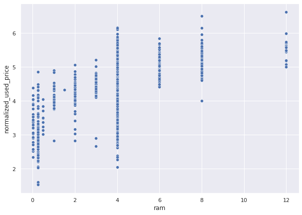

```python
plt.figure(figsize=(10, 7))
sns.scatterplot(data=data, y="normalized_used_price", x="ram");

plt.show()
```

**Observations**

A positive trend is noticed in this scatterplot as confirmed by the correlation heatmap. The plot indicates that as the device RAM increases, so does the deivce price

**Used Price vs Release Year**

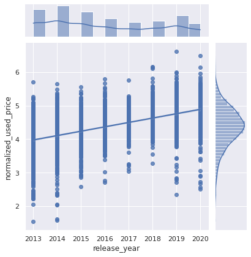

```python
plt.figure(figsize=(10, 7))
sns.jointplot(data=data, x="release_year", y="normalized_used_price", kind = 'reg');
```

**Observations**

- The plot indicates that as release year increases, the used price of devices increases as well.
- Since we analysed above that the standard deviation of the release year data is relatively small compared to the mean, suggesting that the majority of phones were released within a relatively narrow time frame, which could be a contributing factor to the trend of increasing used price as release year increases.
- For example, if most of the phones were released within a few years of each other, it is possible that they share similar features and technologies, making them more comparable in the used market.

**Device Screen Size vs Device Weight**

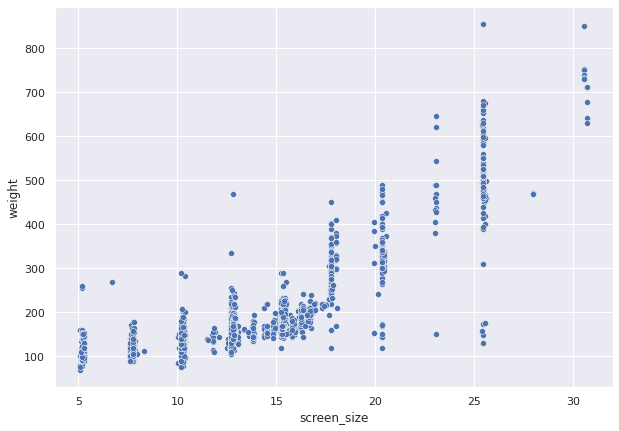

```python
plt.figure(figsize=(10, 7))
sns.scatterplot(data=data, x="screen_size", y="weight");

plt.show()
```

**Observation**

- A correlation coefficient of 0.83 indicates a strong positive correlation between screen size and weight.
- This means that as the screen size of a phone or tablet increases, the weight of the device tends to increase as well.
- This relationship is quite logical, as a larger screen size usually would require a larger battery and more hardware components, which can contribute to the overall weight of the device.

**Weight vs Battery**

*BA 1 : How does the weight vary for phones and tablets offering large batteries (more than 4500 mAh)?*

```python
"""
   To answer this question, we would need to perform a subset analysis on the dataset,
   filtering for phones and tablets that offer large batteries (more than 4500 mAh)

"""

large_battery = data[data.battery > 4500]
print('There is a total of :',large_battery.shape[0], 'refurbished phones wih large batteries > 4500mAh')
```

```
There is a total of : 341 refurbished phones wih large batteries > 4500mAh
```

```python
large_battery["weight"].describe()
```

```
count    341.000000
mean     332.275660
std      155.501832
min      118.000000
25%      198.000000
50%      300.000000
75%      467.000000
max      855.000000
Name: weight, dtype: float64
```

```python
#let us determine how many brands meet the above criteria
large_battery["brand_name"].value_counts()
```

```
Samsung      50
Others       41
Huawei       37
Xiaomi       31
Lenovo       28
Asus         22
Apple        17
Honor        14
Motorola     14
Vivo         13
LG           12
Realme       12
Gionee       10
ZTE          10
Acer          7
Infinix       6
Sony          6
Oppo          4
Alcatel       1
Google        1
HTC           1
Micromax      1
Nokia         1
Panasonic     1
Spice         1
Name: brand_name, dtype: int64
```

```python
large_battery["os"].value_counts()
```

```
Android    324
iOS         14
Others       3
Name: os, dtype: int64
```

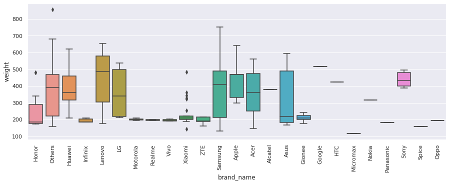

```python
# plot the graph

plt.figure(figsize=(15,5))
sns.boxplot(x="brand_name", y ="weight", data=large_battery)
plt.xticks(rotation=90);
plt.show()
```

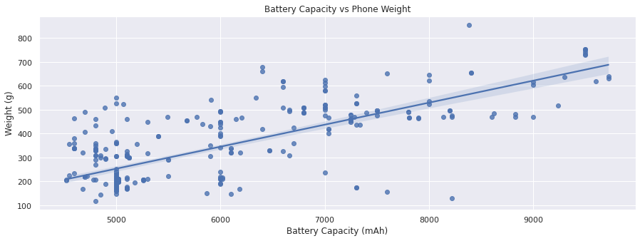

```python
plt.figure(figsize=(15,5))
sns.regplot(x="battery", y ="weight", data=large_battery);
plt.title('Battery Capacity vs Phone Weight')
plt.xlabel('Battery Capacity (mAh)')
plt.ylabel('Weight (g)')
plt.show()
```

**BA2 : What percentage of the used device market is dominated by Android devices?**

```python
device_os = data['os'].value_counts()
device_os
```

```
Android    3214
Others      137
Windows      67
iOS          36
Name: os, dtype: int64
```

```python
device_os.describe()
```

```
count       4.00000
mean      863.50000
std      1567.56935
min        36.00000
25%        59.25000
50%       102.00000
75%       906.25000
max      3214.00000
Name: os, dtype: float64
```

```python
android_devices = data[data['os'] == 'Android']
android_brands = android_devices['brand_name'].value_counts()
print(android_brands)
```

```
Others        465
Samsung       323
Huawei        249
LG            195
Lenovo        171
ZTE           139
Xiaomi        132
Oppo          129
Asus          122
Vivo          117
Honor         116
Alcatel       109
HTC           107
Motorola      106
Micromax      106
Sony           86
Meizu          62
Gionee         56
Acer           48
Panasonic      47
XOLO           47
Nokia          46
Realme         41
Lava           35
Spice          30
Karbonn        29
OnePlus        22
Coolpad        22
Celkon         22
Google         15
BlackBerry     10
Infinix        10
Name: brand_name, dtype: int64
```

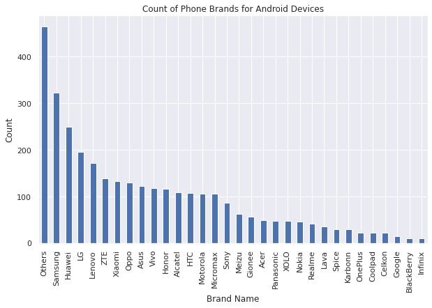

```python
fig, ax = plt.subplots(figsize=(10,6))  # Increase the figure size to (10,6)
android_brands.plot(kind='bar', ax=ax)
ax.set_xlabel('Brand Name')
ax.set_ylabel('Count')
ax.set_title('Count of Phone Brands for Android Devices')
plt.show()
```

*Analysis :*

Based on the given data, it can be inferred that the used device market is dominated by Android devices, with 3214 out of 3454 devices being Android. This represents about 93% of the market share.

Further analysis shows that the top Android brands in the market are Samsung, Huawei, LG, Lenovo, and ZTE, with Samsung being the most popular brand with 323 devices. The other Android brands have a relatively similar distribution of devices in the market.

**BA3 : The amount of RAM is important for the smooth functioning of a device. How does the amount of RAM vary with the brand?**

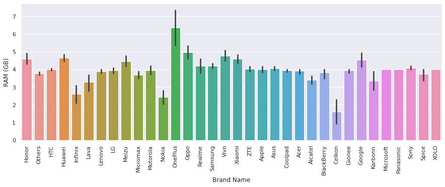

```python
plt.figure(figsize=(15, 5))
sns.barplot(x="brand_name", y="ram", data=data)
plt.xticks(rotation=90)
plt.xlabel('Brand Name')
plt.ylabel('RAM (GB)');
```

**BA3.1 : Which OS offers the highest RAM? OS vs RAM**

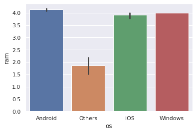

```python
sns.barplot(x="os", y="ram", data=data);
```

*Analysis :*

- OnePlus brand has the highest RAM
- The OS with the highest RAM belongs to Android devices as well.
- While the lowest RAM are belonging to Other OS

**BA4 : Larger screens offer better viewing experience. How many phones and tablets offer a screen size larger than 6 inches?**

```python
# create a dataframe for devices with screensize larger than 6 inches (15.24cm)

large_screen = data[data.screen_size > 15.24].shape[0]    # 1 inch = 2.54 centimetres
print('There is a total of :',large_screen, 'refurbished phones wih screen size > 6inches')
```

```
There is a total of : 1099 refurbished phones wih screen size > 6inches
```

**BA4.1 : Top 5 refurbished brands in ReCell with large screens greater than 6 inches?**

```python
large_screen = data[data['screen_size'] >= 15.24]  # Filter the data to only include phones with screen size >= 6.0in
large_screen_brands = large_screen['brand_name'].value_counts().head()
large_screen_brands
```

```
Huawei     157
Samsung    131
Others     118
Vivo        82
Oppo        78
Name: brand_name, dtype: int64
```

```python
large_screen.describe()
```

|  | screen_size | main_camera_mp | selfie_camera_mp | int_memory | ram | battery | weight | release_year | days_used | normalized_used_price | normalized_new_price |
| --- | --- | --- | --- | --- | --- | --- | --- | --- | --- | --- | --- |
| count | 1228.000000 | 1057.000000 | 1227.000000 | 1228.000000 | 1228.000000 | 1227.000000 | 1228.000000 | 1228.000000 | 1228.000000 | 1228.000000 | 1228.000000 |
| mean | 17.512980 | 9.675307 | 10.921883 | 79.912052 | 4.584283 | 4276.389976 | 247.256963 | 2017.572476 | 508.697883 | 4.767122 | 5.557506 |
| std | 3.293844 | 4.934820 | 8.959354 | 85.595695 | 1.787972 | 1244.921423 | 119.696835 | 2.329176 | 256.992697 | 0.432576 | 0.632206 |
| min | 15.240000 | 0.300000 | 0.300000 | 4.000000 | 0.500000 | 1200.000000 | 118.000000 | 2013.000000 | 91.000000 | 2.667228 | 3.690877 |
| 25% | 15.340000 | 5.000000 | 2.150000 | 32.000000 | 4.000000 | 3500.000000 | 176.000000 | 2016.000000 | 293.000000 | 4.463607 | 5.084845 |
| 50% | 16.230000 | 12.000000 | 8.000000 | 64.000000 | 4.000000 | 4000.000000 | 195.000000 | 2019.000000 | 467.000000 | 4.767374 | 5.523878 |
| 75% | 17.780000 | 13.000000 | 16.000000 | 128.000000 | 4.000000 | 4510.000000 | 292.250000 | 2019.000000 | 691.250000 | 5.037164 | 5.974639 |
| max | 30.710000 | 48.000000 | 32.000000 | 1024.000000 | 12.000000 | 9720.000000 | 855.000000 | 2020.000000 | 1091.000000 | 6.619433 | 7.847841 |

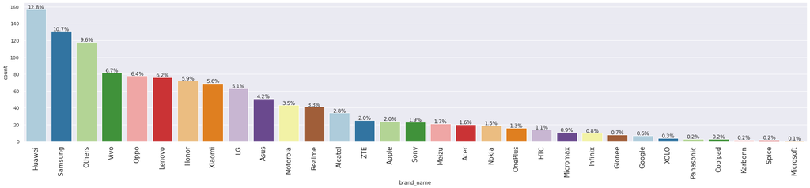

```python
labeled_barplot(large_screen, "brand_name", perc=True);
```

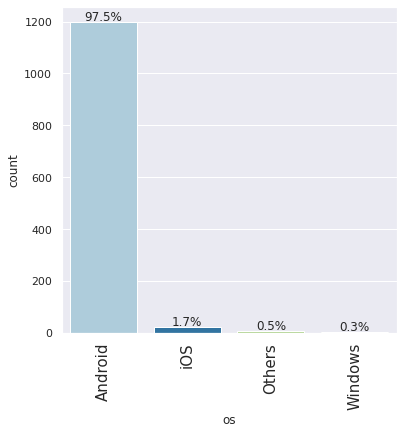

```python
labeled_barplot(large_screen, "os", perc=True);
```

*Analysis :*

In terms of the top 5 refurbished brands with large screens greater than 6 inches, Huawei has the most significant number of devices with 157, followed by Samsung with 131, and others with 118 devices. This information can help ReCell understand the demand for larger-screen devices and focus on refurbishing and reselling devices from these popular brands.